```python
from IPython.display import HTML

HTML('''<script>
code_show=true;
function code_toggle() {
 if (code_show){
 $('div.input').hide();
 } else {
 $('div.input').show();
 }
 code_show = !code_show
}
$( document ).ready(code_toggle);
</script>
<form action="javascript:code_toggle()"><input type="submit" value="Click here to toggle on/off the raw code."></form>''')
```

# La opinión en Twitter sobre el simulacro. Reporte 4

## Sobre el ejercicio:

Construí una red que representa las interacciones de los usuarios de Twitter que publican tuits con los hashtags **"simulacrovital","bogotasequedaencasa","simulacrodeaislamiento","cuarentenaobligatoria bogota", "cuarentenaobligatoria bogotá","yomequedoencasa bogota","yomequedoencasa bogotá","quedateencasa bogotá", "quedateencasa bogota"** y descargué los tuits asociados al tema. Con métodos de análisis de redes y text mining detecté los influenciadores y temas más importantes en esta conversación. Este ejercicio puede replicarse monitoreando cualquier otra palabra clave, hashtag o usuario.

## Hallazgos principales:

La conversación está muy activa y es de reporte y opinión casual :

1. La conversación sobre el simulacro continúa siendo positiva e informativa. **Cada vez toma más importancia los temas operativos** Los trinos más retuiteados son aquellos que explican con claridad a la ciudadanía cómo funcionaremos por los próximos días.
2. La conversación se ha descentralizado. **Claudia dejó de ser el nodo más grande y las distintas entidades distritales han tenido un rol más relevante en la conversación**
3. **La discusión política se ha aplacado** Las conversaciones políticas de la mañana se mantienenm pero cada vez generan menos interacciones.

```python
import json
from bson.json_util import dumps, CANONICAL_JSON_OPTIONS
from bson import Binary, Code
from collections import Counter
import pyperclip
import spacy
from wordcloud import WordCloud
from stop_words import get_stop_words
import string
import altair as alt
import matplotlib.pyplot as plt
nlp=spacy.load('es_core_news_sm')
import pandas as pd
stopwords_es= get_stop_words('es')
import pandas as pd
import networkx as nx
import numpy as np
import matplotlib.pyplot as plt
import collections
import tweepy
import csv
import operator
import community
from IPython.display import Markdown,display
from datetime import datetime
import dateutil
```

```python
from pymongo import MongoClient
client = MongoClient()
db = client.corona
```

## Detección de comunidades

```python
G=nx.read_graphml("/home/laufernanda/Documents/corona-redes/simulacro4.graphml")
print('La red tiene ',G.number_of_nodes(),'usuarios y ',G.number_of_edges(),"interacciones")
```

```
La red tiene  3487 usuarios y  8621 interacciones
```

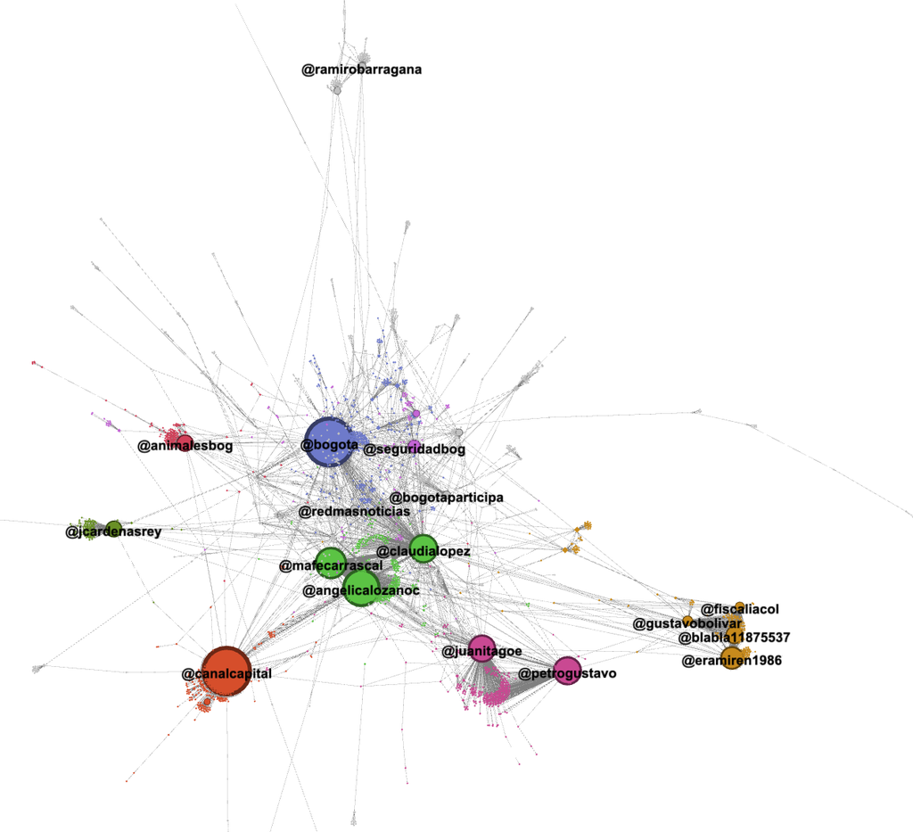

```python
from IPython.display import Image
Image(filename='image4.png')
```

```python
G= nx.DiGraph(G)
centrality = nx.eigenvector_centrality(G)

for node in G.nodes():
    G.nodes[node]["in_degree"]=G.in_degree[node]
    G.nodes[node]["out_degree"]=G.out_degree[node]
    G.nodes[node]["eigenvector"]=centrality[node]
```

```python
H=G.to_undirected()
partition=community.best_partition(H)
for node in G.nodes() :
    G.node[node]['comunidad']= partition[node]
```

```python
#Análisis comunidades
#Tamano comunidades
c=Counter(list(partition.values()))
n=G.number_of_nodes()/20
comunidades_importantes=[]
for k in c.keys():
    if c[k]>= n:
        comunidades_importantes.append(k)
print("La red tiene ", len(comunidades_importantes), " comunidades importantes (tienen más del 5% de los nodos)" )
```

```
La red tiene  6  comunidades importantes (tienen más del 5% de los nodos)
```

```python
top_reacciones={}
top_creadores={}
top_influencers={}
grado_in=sorted(G.in_degree(),key=operator.itemgetter(1),reverse=True)
for comunidad in comunidades_importantes:
    nodos_comunidad=[node for node in G.nodes() if G.nodes[node]['comunidad']==comunidad]
    grado_in=sorted(G.in_degree(nodos_comunidad),key=operator.itemgetter(1),reverse=True)
    grado_out=sorted(G.out_degree(nodos_comunidad),key=operator.itemgetter(1),reverse=True)
    eigen={k:v for k,v in centrality.items() if k in nodos_comunidad}
    eigen=sorted(eigen,key=operator.itemgetter(1),reverse=True)
    top_reacciones[comunidad]=[x[0] for x in grado_in[0:5]]
    top_creadores[comunidad]=[x[0] for x in grado_out[0:5]]
    top_influencers[comunidad]=eigen[0:5]
```

## ¿De qué hablan las comunidades?

1. (Azul en la gráfica)Es una comunidad de **difusión sobre información útil para la cuarentena** liderada por la cuenta oficial de la alcaldía. Por ejemplo: cómo abastecerse o pedir taxi en estos días. El hashtag #PreguntasyRespuestas cobra relevancia.
2. (Verde en la gráfica) Es una comunidad de **discusión política y difusión de información oficial** Resalta la discusión entre la articulación nacional-local entre el simulacro y la cuerentena nacional.
3. (Amarilla en la gráfica) Es una comunidad de crítica a Gustavo Bolívar por no estar aislado. Probablemente sea un nicho de oposición a la izquierda posicionando el mensaje.
4. (Naranja en la gráfica) Es una comunidad de **informativa** liderada por Canal Capital. De difusión de información noticiosa sobre los días que vienen. La excepción de pagos de servicios públicos es el mensaje más relevante.
5. (Rosada en la gráfica) Es una comunidad de **discusión política** motivada por la crítica de Juanita Goebertus de instrumentalizar la situación electoralmente.
6. (Morado en la gráfica) Es una comunidad de **difusión** de información oficial en la que cada entidad (:@seguridadbog, @ipesbogota, @sectormovilidad, @ngalvisarias, @idtbogota) difunde información sobre el funcionamiento de la ciudad los próximos días

```python
tw_iter=db.simulacro.find()
f = open("./twits_simulacro.txt", "a")
for tweet in tw_iter:
    f.write(tweet["text"])
    f.write("\n")
f.close()
```

```python
import pytz
start = datetime(2020, 3, 21, 14, 00, 00, 0, pytz.UTC)
end = datetime(2020, 3, 21, 20, 30, 00, 0, pytz.UTC)
```

**La comunidad 1 tiene 431 usuarios**

**La comunidad 1 habla de:**

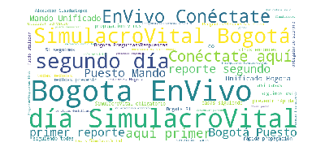

```
Se incluyeron  149 tuits producidos por nodos de esta comunidad
```

**los usuarios que son más retuiteados, mencionados o citados en la comunidad 1 son:**@bogota, @uaesp, @bomberosbogota, @policiacolombia, @transmilenio

```
__________________________________________________________________________________________________________________
```

**los usuarios que retuitean, mencionan y citan más en la comunidad 1 son:**@uaesp, @martinezjulianf, @manuelquimbayov, @svillamil05, @jennivian

**los trinos más retuiteados de la comunidad 1 son:**

|  | _id | count | text | username |
| --- | --- | --- | --- | --- |
| 0 | 1241434216128282625 | 53 | 🔴#EnVivo \| Conéctate aquí al primer reporte del segundo día del #SimulacroVital en Bogotá. Desde el Puesto de Mando Unificado estamos tomando todas las decisiones necesarias para cuidarnos bien todo … | Bogota |
| 1 | 1241419899823628288 | 15 | Si seguimos así, en nuestras casas, y siguiendo todas las medidas para prevenir la rápida propagación del virus, entonces #TodoSaldráBien 👏 Bogotá está dando ejemplo al mundo de responsabilidad, civis… | Bogota |
| 2 | 1241440046340808704 | 9 | #PreguntasYRespuestas ¿Puedo utilizar el servicio de taxis durante el #SimulacroVital obligatorio? 🚕\n\nSí, siempre y cuando se solicite por teléfono o alguna plataforma.\n\n#TodoSaldráBien \n#YoMeQue… | Bogota |
| 3 | 1241418122697101313 | 5 | #PreguntasYRespuestas ¿En dónde se puede denunciar a personas y empresas que están incumpliendo el #SimulacroVital obligatorio?\n\nSe pueden hacer denuncias sobre incumplimiento del Simulacro Vital en… | Bogota |
| 4 | 1241457048807710721 | 5 | Entérate de los súper conciertos virtuales que hay este fin de semana y disfruta de ellos desde la comodidad de tu hogar #YoMeQuedoEnCasa 🏡🖥 🎤 🎶 🎸\n\nhttps://t.co/2qBqMyVmLf | Bogota |
| 5 | 1241429236478627841 | 5 | Desde @BomberosBogota y el #C4 de @Bogota la Alcaldesa @ClaudiaLopez coordina las acciones del PMU durante la jornada del #SimulacroVital 🚒 tu que puedes #QuédateEnCasa https://t.co/EposlQWLAC | BomberosBogota |
| 6 | 1241455175241433092 | 4 | #PreguntasYRespuestas ¿Habrá servicio de domicilios?\n\nSí, pero solo servicios domiciliarios relacionados con atención y cuidado, productos de abastecimiento, alimentos preparados o no, y medicinas.\… | Bogota |
| 7 | 1241440847264186369 | 3 | “Cualquier día podremos salir a abastecernos, en días de simulacro o cuando entre la cuarentena obligatoria que dispuso el Presidente. Tranquilos, una persona por hogar podrá ir cualquier día a compra… | Bogota |
| 8 | 1241149766739902467 | 2 | #EnVivo🔴Conéctese aquí con la alcaldesa @ClaudiaLopez para conocer el segundo reporte del #SimulacroVital en Bogotá. \n\nEs un orgullo ver cómo los ciudadanos están cumpliendo.\n#YoMeQuedoEnCasa https… | Bogota |
| 9 | 1241452032801804289 | 2 | Amar la labor que está haciendo @ClaudiaLopez en estos momentos. Liderazgo y decisiones para no dejar caer a la gente. \n\n"Del 20 de marzo al 20 de abril en @Bogota no se cobraran los servicios públi… | Lopezgrafico |

**los hashtags más usados en la comunidad 1 son:**

|  | _id | count |
| --- | --- | --- |
| 0 | SimulacroVital | 79 |
| 1 | EnVivo | 58 |
| 2 | PreguntasYRespuestas | 21 |
| 3 | C4 | 5 |
| 4 | TodoSaldráBien | 2 |

**La comunidad 2 tiene 463 usuarios**

**La comunidad 2 habla de:**

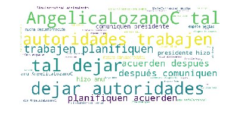

```
Se incluyeron  111 tuits producidos por nodos de esta comunidad
```

**los usuarios que son más retuiteados, mencionados o citados en la comunidad 2 son:**@mafecarrascal, @claudialopez, @angelicalozanoc, @carlosocorrea, @intimesias

```
__________________________________________________________________________________________________________________
```

**los usuarios que retuitean, mencionan y citan más en la comunidad 2 son:**@alexanderojasa, @lizneyde, @jesus07431548, @claudialopez, @angelicalozanoc

**los trinos más retuiteados de la comunidad 2 son:**

|  | _id | count | text | username |
| --- | --- | --- | --- | --- |
| 0 | 1241407551889178627 | 61 | ¿Y qué tal dejar que las autoridades trabajen, planifiquen, acuerden y después comuniquen? \n\nEl presidente hizo el anuncio hace 12 horas\n\n¿Podemos esperar que planifiquen, coordinen y luego inform… | AngelicaLozanoC |
| 1 | 1241407039605178371 | 21 | Hay mucha desinformación sobre cómo será el empate entre las medias del #SimulacroVital y el aislamiento total de 20 días. Necesitamos urgente información aclaratoria @ClaudiaLopez @AngelicaLozanoC @L… | MafeCarrascal |
| 2 | 1241443399162527744 | 5 | None | CarlosOCorrea |
| 3 | 1241440847264186369 | 3 | “Cualquier día podremos salir a abastecernos, en días de simulacro o cuando entre la cuarentena obligatoria que dispuso el Presidente. Tranquilos, una persona por hogar podrá ir cualquier día a compra… | Bogota |
| 4 | 1241224083376930817 | 2 | Mañana continuará el Día 2 de nuestro #SimulacroVitalBogota.\n\nLes comparto el balance de lo que aprendimos hoy.\n\nMañana continuaremos evaluando y aprendiendo para prepararnos para la #CuarentenaNa… | ClaudiaLopez |
| 5 | 1241026486011752448 | 1 | En puente normal habrían salido de Bogota más de un millón de vehículos, ayer solo salieron cerca de 120.000. Espero que hayan sido solo personas que no viven en la ciudad y debían marcharse. En todo … | ClaudiaLopez |
| 6 | 1241434216128282625 | 1 | 🔴#EnVivo \| Conéctate aquí al primer reporte del segundo día del #SimulacroVital en Bogotá. Desde el Puesto de Mando Unificado estamos tomando todas las decisiones necesarias para cuidarnos bien todo … | Bogota |
| 7 | 1241187347368198144 | 1 | 1/7 (HILO)\nLos datos que nos entrega la alcaldesa de #Bogotá @ClaudiaLopez el primer día de #SimulacroVital son espectaculares. Somos una sociedad más madura de lo que muchos pensábamos. #AplaudoANue… | IntiMesias |
| 8 | 1241454829345570817 | 1 | La alcaldesa Claudia López anuncia que entre el 20 de marzo y el 20 de abril, ningún ciudadano pagará servicios públicos en Bogotá →\n\n#YoMeQuedoEnCasa #SimulacroVital obligatorio https://t.co/BG27EZ… | CanalCapital |
| 9 | 1241415493250097153 | 1 | Durante #SimulacroVital nuestra Unidad de Cuidado Animal funciona con normalidad. Todas las áreas de trabajo están cubiertas y las necesidades de los animales que tenemos albergados están atendidas. C… | AnimalesBOG |

**los hashtags más usados en la comunidad 2 son:**

|  | _id | count |
| --- | --- | --- |
| 0 | SimulacroVital | 28 |
| 1 | SimulacroVitalBogota | 2 |
| 2 | CuarentenaPorLaVida | 2 |
| 3 | Bogotá | 1 |
| 4 | BogotaSeQuedaEnCasa | 1 |

**La comunidad 3 tiene 224 usuarios**

**La comunidad 3 habla de:**

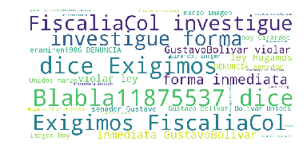

```
Se incluyeron  37 tuits producidos por nodos de esta comunidad
```

**los usuarios que son más retuiteados, mencionados o citados en la comunidad 3 son:**@eramiren1986, @gustavobolivar, @fiscaliacol, @blabla11875537, @thesnowyday14

```
__________________________________________________________________________________________________________________
```

**los usuarios que retuitean, mencionan y citan más en la comunidad 3 son:**@ceciliamr1948, @mauriciobocan19, @kritikonnn, @anagabr94795881, @lebarragan7s

**La comunidad 4 tiene 414 usuarios**

**La comunidad 4 habla de:**

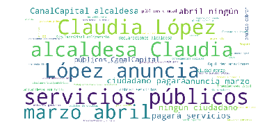

```
Se incluyeron  174 tuits producidos por nodos de esta comunidad
```

**los usuarios que son más retuiteados, mencionados o citados en la comunidad 4 son:**@canalcapital, @theogelves, @animodeofender_, @antoniamendozas, @alcaldiapopayan

```
__________________________________________________________________________________________________________________
```

**los trinos más retuiteados de la comunidad 4 son:**

|  | _id | count | text | username |
| --- | --- | --- | --- | --- |
| 0 | 1241454829345570817 | 103 | La alcaldesa Claudia López anuncia que entre el 20 de marzo y el 20 de abril, ningún ciudadano pagará servicios públicos en Bogotá →\n\n#YoMeQuedoEnCasa #SimulacroVital obligatorio https://t.co/BG27EZ… | CanalCapital |
| 1 | 1241455580478345216 | 12 | Aquí las declaraciones de la alcaldesa sobre el anuncio de no cobrar servicios públicos en la ciudad entre el 20 de marzo y el 20 de abril. | TheoGelves |
| 2 | 1241434324148183041 | 4 | None | CanalCapital |
| 3 | 1241443889099276289 | 3 | None | CanalCapital |
| 4 | 1241457364643037186 | 3 | None | AntoniaMendozaS |
| 5 | 1241456274660876288 | 3 | None | AnimoDeOfender_ |
| 6 | 1241442331498360839 | 2 | En rueda de prensa explican por qué para los ciudadanos es difícil quedarse en casa durante #SimulacroVital obligatorio → https://t.co/rA67JcsTeG | CanalCapital |
| 7 | 1241454910442528771 | 2 | Claudia López anuncia que en Bogotá quedará suspendido el cobro de servicios públicos entre el 20 de marzo y el 20 de abril por cuarentena general obligatoria. \n#TodoSaldráBien https://t.co/EecXejxzD… | Bogota__DC |
| 8 | 1241457244807495685 | 2 | None | Thayito_ |
| 9 | 1241448131109310473 | 1 | ¿Qué tan probable ven los ciudadanos la posibilidad de contagiarse de coronavirus? →\n\n#YoMeQuedoEnCasa #SimulacroVital obligatorio https://t.co/19upVSIfhj | CanalCapital |

**La comunidad 5 tiene 322 usuarios**

**La comunidad 5 habla de:**

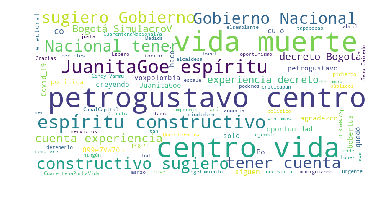

```
Se incluyeron  35 tuits producidos por nodos de esta comunidad
```

**los usuarios que son más retuiteados, mencionados o citados en la comunidad 5 son:**@juanitagoe, @petrogustavo, @platom___, @uriasv, @fernapaba

```
__________________________________________________________________________________________________________________
```

**los usuarios que retuitean, mencionan y citan más en la comunidad 5 son:**@victoriamatt_, @fm20420368, @douglas39337417, @garrotiando, @juanitagoe

**La comunidad 6 tiene 187 usuarios**

**La comunidad 6 habla de:**

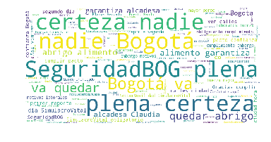

```
Se incluyeron  38 tuits producidos por nodos de esta comunidad
```

**los usuarios que son más retuiteados, mencionados o citados en la comunidad 6 son:**@seguridadbog, @ipesbogota, @sectormovilidad, @ngalvisarias, @idtbogota

```
__________________________________________________________________________________________________________________
```

**los usuarios que retuitean, mencionan y citan más en la comunidad 6 son:**@sectormovilidad, @bogotabureau, @nikolai68843464, @edgarps_ie, @miguelrico10

**los trinos más retuiteados de la comunidad 6 son:**

|  | _id | count | text | username |
| --- | --- | --- | --- | --- |
| 0 | 1241447570385383425 | 10 | "Tengan la plena certeza de que nadie en Bogotá se va a quedar sin abrigo y sin alimento", garantiza la alcadesa @ClaudiaLopez. ¡#TodoSaldráBien! Mientras ustedes dicen "#YoMeQuedoEnCasa", nosotros tr… | SeguridadBOG |
| 1 | 1241401464058269696 | 5 | ¡Gracias por cumplir este pacto de confianza, Bogotá! 💙💜\n\nAsí se ven las calles de nuestra ciudad a esta hora, durante el segundo día del #SimulacroVital obligatorio. \n\n#TodoSaldráBien si cada uno… | SeguridadBOG |
| 2 | 1241425216741486592 | 4 | El #SimulacroVital es de obligatorio cumplimiento. Sin embargo, por motivos laborales o de fuerza mayor, algunas personas deben salir de casa. Si eres uno de ellos, cumple con las normas de tránsito, … | SectorMovilidad |
| 3 | 1241434216128282625 | 3 | 🔴#EnVivo \| Conéctate aquí al primer reporte del segundo día del #SimulacroVital en Bogotá. Desde el Puesto de Mando Unificado estamos tomando todas las decisiones necesarias para cuidarnos bien todo … | Bogota |
| 4 | 1241385178179796994 | 2 | Gente, las Plazas de Mercado Distritales han habilitado servicios de domicilio para que #NosQuedemosEnCasa y sigamos consumiendo productos frescos.\n\nAyúdenos a compartir este directorio telefónico y… | ngalvisarias |
| 5 | 1241425287994376192 | 1 | #TodoEstaráBien \| Desde @Bogota seguimos trabajando en planes de contingencia y demás acciones que permitan afrontar la situación del COVID 19. \n\nEl #SimulacroVital obligatorio nos permitirá cuidar… | LuzAmparoMedina |
| 6 | 1241415493250097153 | 1 | Durante #SimulacroVital nuestra Unidad de Cuidado Animal funciona con normalidad. Todas las áreas de trabajo están cubiertas y las necesidades de los animales que tenemos albergados están atendidas. C… | AnimalesBOG |
| 7 | 1241438872875216897 | 1 | #ATENCIÓN \| Primer reporte de la Alcaldesa @ClaudiaLopez del segundo día del #SimulacroVital en Bogotá. \n\n➡️Todos los supermercados, tiendas, panaderías, Corabastos, están abastecidos.\n\n➡️En esto… | BogotaParticipa |
| 8 | 1241444814467608583 | 1 | None | rcnradio |
| 9 | 1241440847264186369 | 1 | “Cualquier día podremos salir a abastecernos, en días de simulacro o cuando entre la cuarentena obligatoria que dispuso el Presidente. Tranquilos, una persona por hogar podrá ir cualquier día a compra… | Bogota |

**los hashtags más usados en la comunidad 6 son:**

|  | _id | count |
| --- | --- | --- |
| 0 | SimulacroVital | 11 |
| 1 | EnVivo | 4 |
| 2 | NosQuedemosEnCasa | 2 |
| 3 | YoMeQuedoEnCasa | 1 |
| 4 | ATENCIÓN | 1 |

```python
count=0
for comunidad in comunidades_importantes:
    count+=1
    display(Markdown(str("**La comunidad "+ str(count)+ " tiene "+ str(c[comunidad])+" usuarios**")))
    display(Markdown(str("**La comunidad "+ str(count)+ " habla de:**")))
    nodos_comunidad=[node for node in G.nodes() if G.nodes[node]['comunidad']==comunidad]
    nodos_comunidad=[sub.replace('@', '') for sub in nodos_comunidad]
    tw_iter=db.simulacro.find({"user.screen_name":{"$in":nodos_comunidad}})
    text=[]
    ids_filtrados=[]
    for tweet in tw_iter:
        tw=tweet
        date_tuit=dateutil.parser.parse(tw["created_at"])
        if(start<date_tuit< end):
            ids_filtrados.append(tw['_id'])
            text.append(tweet["text"])
    if len(text)>=1:
        text_s=" ".join(text)
        text_s=text_s.replace("https"," ")
        text_s=text_s.replace("RT"," ")

        wordcloud =  WordCloud(scale=2, max_words=2000,relative_scaling=0.5,background_color ='white',stopwords=stopwords_es).generate(text_s)

        plt.imshow(wordcloud)
        plt.axis("off")
        plt.show()
    print("Se incluyeron ",len(text), "tuits producidos por nodos de esta comunidad")

    display(Markdown(str("**los usuarios que son más retuiteados, mencionados o citados en la comunidad "+ str(count) + " son:**"+
                         ", ".join(top_reacciones[comunidad]))))
    print("__________________________________________________________________________________________________________________")

    display(Markdown(str("**los usuarios que retuitean, mencionan y citan más en la comunidad "+ str(count) + " son:**"+
                         ", ".join(top_creadores[comunidad]))))
    #print("__________________________________________________________________________________________________________________")
    #display(Markdown(str("**los usuarios con mayor influencia en la comunidad "+ str(comunidad) + " son:**"+
    #                     ", ".join(top_influencers[comunidad]))))
    #print("__________________________________________________________________________________________________________________")
    display(Markdown(str("**los trinos más retuiteados de la comunidad "+ str(count) + " son:**")))
    nodos_comunidad=[node for node in G.nodes() if G.nodes[node]['comunidad']==comunidad]
    nodos_comunidad=[sub.replace('@', '') for sub in nodos_comunidad]

    #Top most retweeted tweets
    tw_iter_RT = db.simulacro.aggregate([
        {"$match": {
            "$and":[ {"retweeted_status": {"$exists": True}},
                   {"_id":{"$in":ids_filtrados}}
                   ]}},
        {"$replaceRoot": { "newRoot": "$retweeted_status" }},
        {"$group" : {"_id":"$id",
                     "text":{"$last":"$extended_tweet.full_text"},
                     "username":{"$last":"$user.screen_name"},
                     "count":{"$sum":1}}},
        {"$sort": {"count": -1}}
        ])
    try:
        top = [tw_iter_RT.next() for i in range(10)]
        df= pd.DataFrame(top)
        pd.set_option("max_colwidth",300)
        display(df)
    except:
        top = list(tw_iter_RT)
        df= pd.DataFrame(top)
        display(df)
        print(no hay info disponible)


    display(Markdown(str("**los hashtags más usados en la comunidad "+ str(count) + " son:**")))

    #Hashtgas
    #Top most used hashtags
    tw_iter_HT = db.simulacro.aggregate([
        {"$match":{"_id":{"$in":ids_filtrados}}},
        {"$unwind": "$entities.hashtags"},
        {"$group" : {"_id":"$entities.hashtags.text",
                   "count":{"$sum":1}}},
        {"$sort": {"count": -1}}
    ])
    try:
        top = [tw_iter_HT.next() for i in range(5)]
        df= pd.DataFrame(top)
        display(df)
    except:
        top = list(tw_iter_HT)
        df= pd.DataFrame(top)
        display(df)
        print(no hay info disponible)
```

[output not shown]

## Lista twitteros importantes en la conversación

```python
usuarios_importantes=[]
for comunidad in comunidades_importantes:
    usuarios_importantes.extend(top_reacciones[comunidad])
    usuarios_importantes.extend(top_creadores[comunidad])
    #usuarios_importantes.extend(top_influencers[comunidad])

usuarios_importantes=set(usuarios_importantes)

f = open("./twitteros_importantes_conversación_simulacro2.txt", "a")
for line in usuarios_importantes:
    f.write(line)
    f.write("\n")
    print(line)
f.close()
```

```
@intimesias
@gustavobolivar
@seguridadbog
@ceciliamr1948
@petrogustavo
@garrotiando
@antoniamendozas
@policiacolombia
@kritikonnn
@anagabr94795881
@animodeofender_
@jennivian
@miguelrico10
@colombia_alert
@pabloov_
@lebarragan7s
@blabla11875537
@elprinc05621638
@thesnowyday14
@platom___
@alexanderojasa
@douglas39337417
@manuelquimbayov
@bomberosbogota
@claudialopez
@jesus07431548
@svillamil05
@alcaldiapopayan
@sectormovilidad
@canalcapital
@carlosocorrea
@lizneyde
@victoriamatt_
@andydiaz_col
@ngalvisarias
@duarteakemy
@eramiren1986
@theogelves
@martinezjulianf
@mauriciobocan19
@bogota
@bogotabureau
@idtbogota
@edgarps_ie
@angelicalozanoc
@uriasv
@fernapaba
@nikolai68843464
@fm20420368
@mafecarrascal
@fiscaliacol
@ipesbogota
@juanitagoe
@transmilenio
@uaesp
```